# teleartikkel

Andres Karjus

11/07/2021

Oluline: siin on praegu ainult deskriptiivsed graafid, statistilist modelleerimist veel ei tee (üks asi et enne oleks vist ülevaade hea, teisalt see eeldaks küsimuste ümbersõnastamist testitavate hüpoteesidena).

# 1 Saadete toodangu tüübid

> 1.1. kuidas aastate lõikes on omatoodangu, koostöösaadete, tellitud saadete ja hankesaadete vahekorrad on muutunud; - kas on tegu ERRi omatoodanguga või koostöösaatega, tellitud saate või hangitud saatega. (Vt ERRi “Codes” failis - “toodangu liik/Acquisition type”); kas ERR
> - sekkub turule/pakub ise väärtust (omatoodang)
> - või toodab seda koostöös partneritega (koostöösaade või tellitud saade)
> - või tellib valmistoodangut lihtsalt (hangitud saade).

> Kindlasti tuleb veel vaadata ka eetrimahtude järgi - et millsed on reaalsed vahed, kui vaadata saadete kestust.

Siin all on ainult REF_EETRI_TUUP==“saade” tüüp, st välja on jäetud “promo” (mängukavad, saatekavad - kõige suurem klass kannete arvu poolest) ja “ident” (vaheklipid, hoiatused), samuti “kultuuriteated” jms väiksemad klassid.  
Siin periood 2004-2020, ehk vahemik kus eetriaegade tabelis on kõigil saadetel saatepikkus olemas, ja mis on täisaastad (2021 on poolik veel, enne 2004 on pool kuni kolmandik kandeid augulised, ja oluliselt vähem sissekandeid kui pärast).  
“Vahetussaadete” osakaal on väike, sest need on asjad nagu Eurovisioon (mis on ilmselt päris olulised/vaadatavad, aga harvad).

Ma teen praegu kõik graafikud summeeritud eetri-tundides mitte sissekannete arvedega, sest saadete pikkused on varieeruvad 10 minutist 10 tunnini. Need siin üksteise all moodustavad mingi mõttekäigu, mis peaks vastama sellele ülal olevale küsimusele selle kohta, kuidas oma-tellitud-hangitud jaotuvad aastate lõikes.

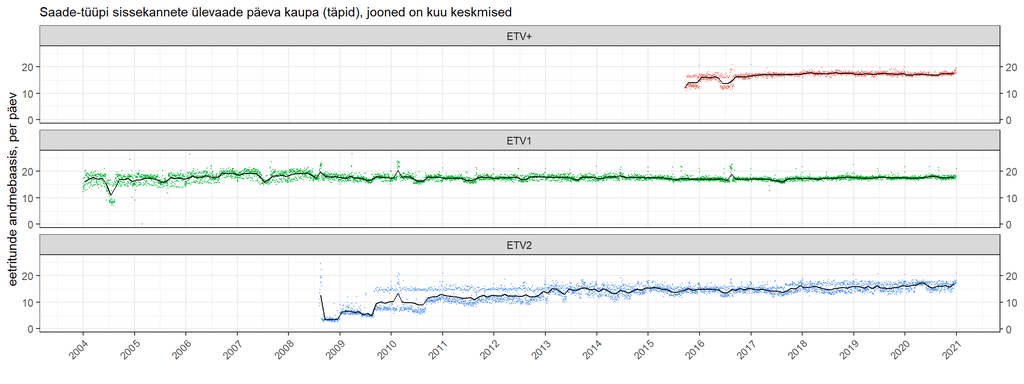

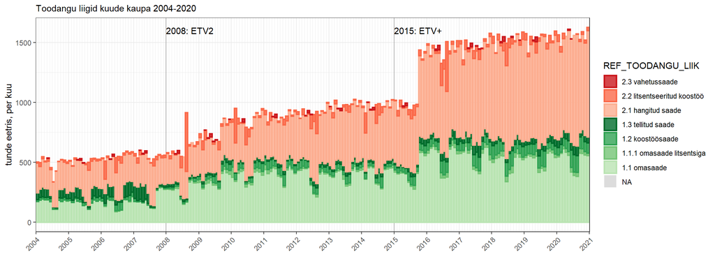

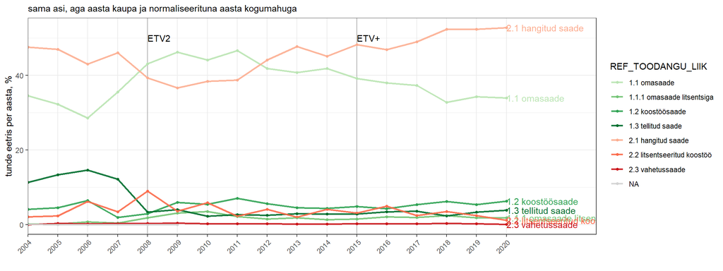

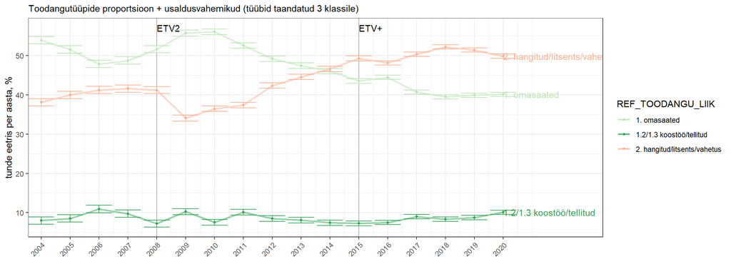

> 1.2. kas ERR võiks teha rohkem koostööd sõltumatute tootjatega, sest siis tõmmatakse nö tööstust käima ja kaasatakse rohkem ideid.

-Andmed seda otseselt ei ütle mida *peaks* tegema või võiks teha; filosoofilisem küsimus.

> 1.3. Ja kui hangitakse väljast, siis 1.3.1. miks 1.3.2. ja millistes valdkondades, (kas mõnes olulises kultuuripoliitilsies valdkonnas domineerib kultuuriliselt kauge välistoodang või vastupidi: kultuuriline variatiivsus on liiga madal).

*Miks* ja *liiga* on samuti võrdlemisi keerulised ja osaliselt subjektiivsed. Tootjariigi saab aga välja võtta küll:

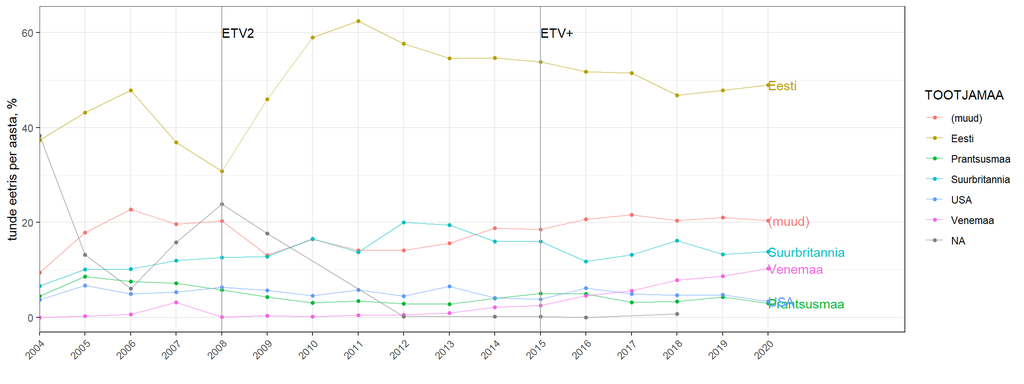

Tundub et need puuduolevad kirjed (hall, NA) on võivad tulla muudatusest andmete sisestamisel - ilmselt enne 2012 pole kõigil Eestis toodetud asjadel riiki küljes (nt Aktuaalne Kaamera, Sport), aga samas on seal ka kirjeid kus riik ja aasta on olemas, aga vales lahtris , st pole eraldi tõstetud (nt nime-lahtris “*Suured kunstnikud. Rembrandt. Isad ja pojad (Kanada 1999)*”).

# 2 Valdkonnad

> 2. Teisena saaks hakata vaatama, et milliseid saatevaldkondi (“Valdkond” ja “Alamvaldkond” kooditabelis)
> - kas toodetakse ise (omasaated),
> - tehakse suuremas koostöös (koostöösaated),
> - tellitakse konkreetselt (tellimussaated)
> - või hangitakse (hankesaated).

(ma teen siin praegu väikse lihtsustuse ja lükkan kaks keskmist kokku, et oleks sama kolmene jaotus mis ülal)

> Võiks võtta näiteks iga tootmisliigi raames 10 enamesinevat alamvaldkonda. Ja vaadata samuti muutusi aastate lõikes.

Hmm no kui 10 siis ma võin juba implementeerida selle grupeerimise mis ennist saatsid:

> - 1.1, 1.2, 1.3, 1.4, 1.5, 1.8 - lavastatud sisu (filmid ja sarjad)
> - 1.6 - animatsioon [see kood esines siin ja ülal, eeldan et siinne on vaja eraldi]
> - 2.1, 2.2 - mängud ja meelelahutuslikud võistllused
> - 2.3, 2.5, 2.6 - meelahutus ja elustiili saated
> - 2.4 - huumori- ja satiirisaated
> - 3.1, 3.2, 3.3, 3.4 - muusika
> - 4.1, 4.2, 4.3, 4.4 - sport
> - 5.1, 5.2 - uudistesaated [siin oli 5.1-5.1, oletan et 5.2 peaks ka]
> - 6.1, 6.2, 8.1 - päevakajalised poliitikasaated ja arvamussaated
> - 6.3, 6.4, 8.3, 8.4 informeerivad saate erinevatel üldisematel teemadel
> - 8.5 - dokumentaalseriaalid
> - 9.1, 9.2, 9.3, 9.4 - kultuur
> - 9.5 - teadus
> - 10.1, 10.2, 10.3 - haridussaated
> - 11.1, 11.2, 11.3 - ususaated

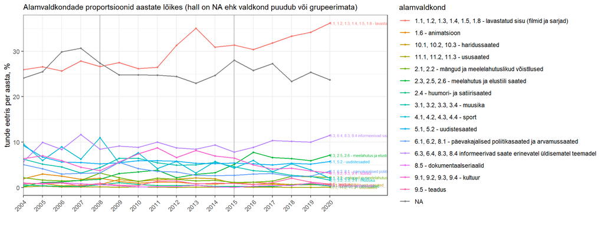

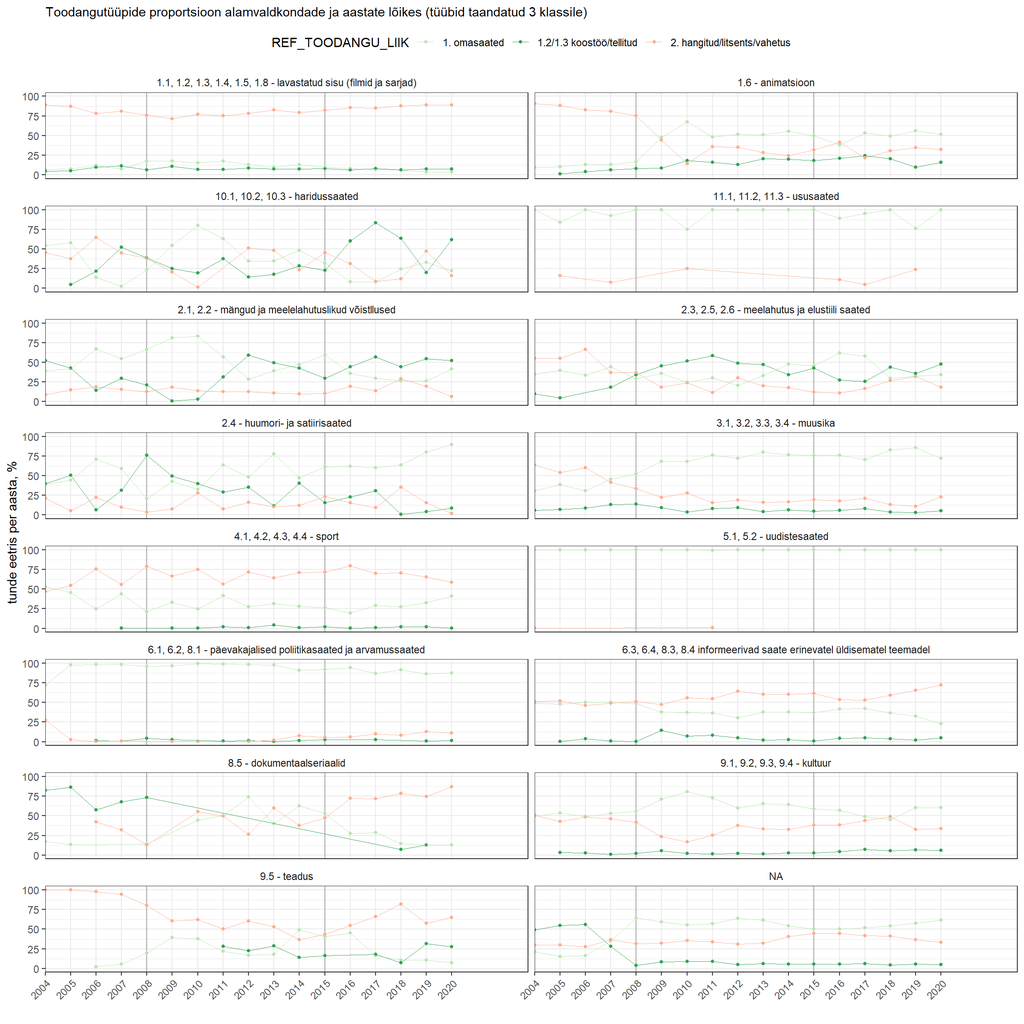

(mida nüüd selle joontelaviiniga edasi teha, ma veel ei tea)

Muu tekst küsimusteks/tükkideks võetuna, veel graafe pole:

> 3.1 Lisaks võiks hanke, koostöö ja tellimussaadete osas vaadata kohe ka peamist tootmisriiki - ja taaskoord aastate lõikes.

> 3.2. Samuti võiks vaadata, kuidas hankesaadete osas on aastate lõikes muutunud tootmisaasta - kui vana või värske toodang meie ekraanidele jõuab.

> 3.3.1 Seonduvalt võiks kohe vaadata ka, et kui palju iga saade eetrisse jõuab - ehk kui palju on kordusi ja kuidas on see aastate jooksul muutunud - sest teada ju on, et ERR näitab eetri täitmiseks kordusi palju ja huvitav oleks vaadata, et kas ka siin on aastate lõikes mingit dünaamikat.

> 3.3.2. Ja hiljem võiks vaadata ka, et millist tootanguliiki korratakse rohkem või vähem.
> 4. Aga ilmselt saaks hakata mõtlema, kuidas žanreid juurde võtta sinna. Lisaks saaks ilmselt tuua sisse ka saadete peamise eesmärgi (“Eesmärk” kooditabelis) ja sihtrühma (“sihtrühm”). Samuti saaks hakata võrdlema valdkondi, žanreid, eesmärki ja sinu pakutud sünopsise analüüsi.